# Árboles de Clasificación y regresión

Introducción al Aprendizaje Estadístico

Kael Huerta, Enrique Bonilla

2016-07-13

### Nota: los paquetes que se utilizaran en estas notas son los siguientes:

```r
require(ggplot2)
require(plyr)
require(dplyr)
require(tidyr)
require(gtools)
require(mlbench)
require(partykit)
require(Formula)
```

# Árboles estadísticos

Como se mencionó anteriormente, dos problemas de CART son el sobre-ajuste por tamaño y cuando hay variables categóricas con muchas categorías. En esta sección se propondrán dos métodos que dan solución al problema usando el enfoque de *Data modeling culture*: **CHI Square Automatic Interaction Detector (CHAID)** y **Conditional Trees (CTrees)**.

Kass (1980)

Hothorn, Hornik, and Zeileis (2006)

Estos métodos utilizan el concepto de significancia estadística para seleccionar las variables y cortes que construirán nuestro árbol. Así, se consideran sólo aquellos efectos que mejoren significativamente el árbol y se podrá dar una interpretación estadística.

## CHAID

Este método se basa en el análisis exhaustivo de tablas de contingencia  
(problema de clasificación) o pruebas ANOVA (problema de regresión), para determinar las mejores variables explicativas y su relación.

Al igual que CART, CHAID puede ser representado mediante la estructura de un árbol, sin embargo, no utiliza árboles binarios. El algoritmo CHAID genera el número de cortes $m$ que crea necesario para hacer particiones significativas. Además, a diferencia de CART, en este algoritmo sólo se pueden usar covariables categóricas.

Dado que el caso de regresión es muy parecido al de clasificación, en esta sección sólo explicaremos el segundo.

En el caso de clasificación, se utilizan pruebas **Chi-cuadradas de Pearson** para determinar si alguna covaraiable divide a la variable respuesta $G$ significativamente. Es decir, para toda covariable $X_j$ se construye una tabla de contingencia contra $G$ para saber, por medio de una prueba de hipótesis, si existen patrones de agrupamiento de la variable respuesta según las categorías de $X_j$.

Hipótesis nula de independencia entre una covariable y la variable respuesta. Se calcula el estadístico Chi-cuadrada de Pearson $X^2= \sum\limits_{j=1}^J\sum\limits_{i=1}^I \frac{ (n_{ij} - \hat{m_{ij}} )^2 }{ \hat{m_{ij}}}$ y se computa el valor $p = P(\chi^2 > X^2)$.

Por ejemplo, si $X_j$ tuviera 3 categorías$\{A,B,C\}$ y $G$ fuera una variable binaria $\{0,1\}$ se podría notar que la mayoría de los $0$ se encuentran en la categoría $A$ y $C$ y los $1$ en la categoría $B$, en cuyo caso, dependiendo de la significancia que se elija, se podría rechazar la hipótesis nula.

Este procedimiento se repite para todos los nodos que se vayan creando, empezando por el nodo inicial, hasta que ya no se puedan partir ningún nodo.

Los pasos para juntar las categorías son más detallados. Además, utilizan métodos como el ajuste de Bonferroni para optimizar el calculo de los valores $p$ con las nuevas categorías. Se recomienda ver la el documento ubicado en la página http://www.unige.ch/ses/metri/cahiers/2010_02.pdf .

Para predecir en estos árboles se pueden usar los criterios usados en CART. Sin embargo, es probable que CART los supere ya que están construidos para este fin. CHAID es bueno para describir los datos y encontrar variables significativamente importantes con interacciones.

Las principales desventajas de este método son que necesita muchos datos (cortes no binarios y número de datos en las tablas de contingencia) y que no se pueden usar covariables numéricas. Además de que la libera CHAID se descontinuó para versiones de **R** a partir de la versión 3.3.

Las desventajas mencionadas se corrigen en el método de árboles condicionales.

## CTrees

Los CTrees tratan de obtener lo mejor de los dos mundos: buscan covariables significativas para crecer el árbol pero aprovechan ideas de CART como cortes binarios y cortes sucedáneos para mejorar su desempeño.

Al igual que CHAID, estos árboles buscan covariable y cortes significativos que separen los datos del nodo en turno. Denotaremos como $w = (w_1,\ldots, w_n)$ con $w_i \in \{0,1\}$ a los pesos de los datos (**case weights**) . Toman el valor $w_i = 1$ si el individuo $i$ se encuentra en el nodo que se está analizando y $w_i = 0$ en caso contrario.

Se pueden tomar valores $w_i \geq 0$ para ponderar los datos.

También como en CHAID, necesitamos decidir si hay información de la variable respuesta que puede ser explicada por alguna de las covariables. En cada nodo, representado por el vector de pesos $w$ se busca rechazar la hipótesis global de independencia en términos de $P$ hipótesis parciales, i.e, $H^j_0 : F(Y \mid X_j) = F(Y)$ con $H_0 = \cap H_0^j$

Se usará $P$ en lugar de $p$ para denotar el número de covariables y así distinguir del valor $p$.

Cuando no es posible rechazar $H_0$ para un nivel predeterminado $\alpha$ paramos la recursión. Cuando la rechazamos, medimos la asociación entre $Y$ y $X_j$ con ayuda de los valores $p$ y elegimos la variable que tenga mayor asociación, es decir, valor $p$ más pequeño.

En CHAID utilizábamos pruebas chi-cuadrada para medir la asociación entre $Y$ y $X$, en los CTrees utilizaremos **estadísticos de prueba** de la forma

$T_j(\Gamma, w) = vec(\sum\limits_{i=1}^nw_ig_j(X_{ji})h(Y_i,(Y_1, \ldots, Y_n))^T) \in {\rm I\!R}^{p_jq}$

Donde $\Gamma$ es la muestra de entrenamiento, $w$ son los pesos, $g_j : X_j \rightarrow {\rm I\!R}^{P_j}$ es una transformación no aleatoria de la covariable $X_j$, $h : Y\times Y^n \rightarrow {\rm I\!R}^q$ es la **función de influencia** que depende de $(Y_1, \ldots, Y_n$ a través de una permutación simétrica y, finalmente, la matriz $p_j \times q$ es transformada en una columna de dimensión $p_jq$ mediante el operador $vec$.

Este tipo de estadístico de prueba permite usar variables respuesta y covariables de cualquier tipo

La distribución de $T_j(\Gamma, w)$ bajo $H^j_o$ depende de la distribución conjunta de $Y$ y $X_j$ la cual es desconocida en la mayoría de las circunstancias. Sin embargo, bajo la hipótesis nula uno puede deshacerse de esta dependencia fijando las covariables y condicionando en todas las permutaciones de la variable respuesta. Este principio lleva al procedimiento llamado **permutation test**.

Strasser and Weber (1999)

El permutation test consiste en usar un procedimiento no paramétrico para obtener la distribución del estadístico de prueba bajo la hipótesis nula, por medio de calcular todos los valores posibles del estadístico de prueba bajo reordenamientos de las $y$ de los datos observados.

En general

- Si la variable respuesta y la covariable es numérica puedes elegir a $g$ y $h$ como la identidad y calcular la correlación entre la covariable $X_j$ y todas las posible permutaciones de la variable respuesta. De ahí, se calcula el valor $p$ de este permutation test y lo comparas con los de las otras covariable.
- Si las covariables y la variable respuesta son categóricas, el estadístico de prueba se puede calcular a través de tablas de contingencia.
- Se pueden hacer estadísticos de prueba de todo tipo de transformaciones y para todo tipo de covariables a partir de este esquema general.

  Para mayor información, se recomienda consultar la sección 5 de Hothorn, Hornik, and Zeileis

```r
## Ejemplo
## Método: Permutation test para respuesta y covariable numérica.
## Librerias: gtools

## Datos
y <- c(1,3,4,5,5); xj <- c(2,2,5,4,5)

## Todas las posibles perutaciones de Y
perms <- permutations(5,5,y,set=FALSE)

## Se calcula la correlación de todas las permutaciones
## de Y con la covariable :
cors <- apply(perms, 1, function(perms_row) cor(perms_row,xj))
cors <- cors[order(cors)]
cors
```

```
##   [1] -0.86692145 -0.86692145 -0.86692145 -0.86692145 -0.76840765
##   [6] -0.76840765 -0.76840765 -0.76840765 -0.66989385 -0.66989385
##  [11] -0.66989385 -0.66989385 -0.66989385 -0.66989385 -0.66989385
##  [16] -0.66989385 -0.57138004 -0.57138004 -0.57138004 -0.57138004
##  [21] -0.47286624 -0.47286624 -0.47286624 -0.47286624 -0.47286624
##  [26] -0.47286624 -0.47286624 -0.47286624 -0.37435244 -0.37435244
##  [31] -0.37435244 -0.37435244 -0.37435244 -0.37435244 -0.37435244
##  [36] -0.37435244 -0.27583864 -0.27583864 -0.27583864 -0.27583864
##  [41] -0.27583864 -0.27583864 -0.27583864 -0.27583864 -0.27583864
##  [46] -0.27583864 -0.27583864 -0.27583864 -0.27583864 -0.27583864
##  [51] -0.27583864 -0.27583864 -0.07881104 -0.07881104 -0.07881104
##  [56] -0.07881104 -0.07881104 -0.07881104 -0.07881104 -0.07881104
##  [61]  0.01970276  0.01970276  0.01970276  0.01970276  0.01970276
##  [66]  0.01970276  0.01970276  0.01970276  0.21673036  0.21673036
##  [71]  0.21673036  0.21673036  0.21673036  0.21673036  0.21673036
##  [76]  0.21673036  0.31524416  0.31524416  0.31524416  0.31524416
##  [81]  0.31524416  0.31524416  0.31524416  0.31524416  0.31524416
##  [86]  0.31524416  0.31524416  0.31524416  0.41375796  0.41375796
##  [91]  0.41375796  0.41375796  0.41375796  0.41375796  0.41375796
##  [96]  0.41375796  0.51227176  0.51227176  0.51227176  0.51227176
## [101]  0.51227176  0.51227176  0.51227176  0.51227176  0.70929937
## [106]  0.70929937  0.70929937  0.70929937  0.80781317  0.80781317
## [111]  0.80781317  0.80781317  0.80781317  0.80781317  0.80781317
## [116]  0.80781317  0.90632697  0.90632697  0.90632697  0.90632697
```

```r
## Para el valor p: compara la correlación de Y y X_j con
## el vector ordenado de la correlación de todas las
## permutaciones.
length(cors[cors>=cor(y,xj)])/length(cors)
```

```
## [1] 0.1
```

```r
## Resultado: 0.1, es decir. valor p de .1
## Notar que en este caso es una prueba de hipótesis
## compuesta de un solo lado.
```

Aunque se puede usar una generalización de $T_j(\Gamma,w)$ para calcular el valor $p$ de $H_0$, en la práctica se calcula el valor $p$ de todas las hipótesis parciales. Si al menos una es menor a un nivel $\alpha$, se rechaza $H_0$ y se selecciona la variable con menor valor $p$ para particionar el nodo. En caso contrario, se acepta $H_0$ y se detiene la recursión.

ver la sección 4 de Hothorn, Hornik, and Zeileis

Para elegir la constante de corte del nodo, se pueden utilizar las técnicas de CART. Sin embargo, generalmente se utiliza una generalización del estadístico de prueba para determinar el corte binario más significativo.

ver la sección 4 de Hothorn, Hornik, and Zeileis

Los cortes sucedáneos que se elijen son aquellas variables que puedan aproximar el corte obtenido por la variable $X_j$ mediante el procedimiento anterior. En el paquete de $R$ debes de especificar cuantos cortes sucedáneos quieres. El valor predeterminado es 0.

# Ejemplo

Ctrees clasificación.

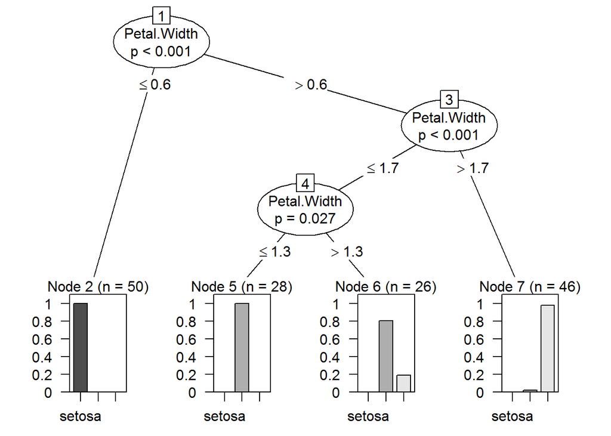

```r
## Método: CTree
## Datos: flores de Fisher
## Librerias: paritykid, Formula

## Modelo
modelo <- ctree(formula = Species ~ Sepal.Width + Petal.Width, data = iris)
plot(modelo)
```

Ctrees regresión.

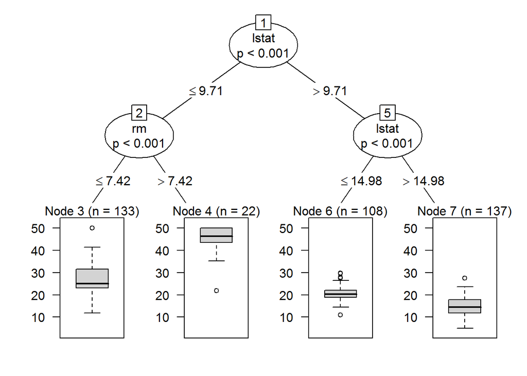

```r
## Método: CTree
## Datos: Boston Housing (librería mlbench)
## Librerias: partykit, Formula

data(BostonHousing)
set.seed(15)
train <- sample(1:nrow(BostonHousing),400)
BostonHousing$train <- F
BostonHousing$train[train] <- T
entrena.arb <- BostonHousing[BostonHousing$train,]
prueba.arb <- BostonHousing[!BostonHousing$train,]
entrena.arb$train <- NULL

## Modelo visible
control.visible <- ctree_control(maxdepth =  2)
modelo <- ctree(medv~. , data = entrena.arb, control = control.visible)
plot(modelo)
```

```r
## Modelo completo
modelo <- ctree(medv~., data = entrena.arb)

## Error de predicción
mean((predict(modelo, prueba.arb)- prueba.arb$medv)^2)
```

```
## [1] 19.68074
```

También existe el concepto de bosques condicionales (Cforest) y se encuentra programado en la librería **partykit**.

Como nota, al usar cualquiera método de un sólo árbol en **R** (CART, Ctrees o CHAID) existe un parámetro de la función que se llama **control**. En este parámetro de control se pueden especificar cosas extras de los árboles: número mínimo de individuos en los nodos, número de cortes sucedáneos, etc. Para mayor información se recomienda leer el CRAN de cada función.

Hothorn, Torsten, Kurt Hornik, and Achim Zeileis. 2006. “Unbiased Recursive Partitioning: A Conditional Inference Framework.” *Journal of Computational and Graphical Statistics* 15 (3). Taylor & Francis: 651–74.

———. “Ctree: Conditional Inference Trees.”

Kass, Gordon V. 1980. “An Exploratory Technique for Investigating Large Quantities of Categorical Data.” *Applied Statistics*. JSTOR, 119–27.

Strasser, Helmut, and Christian Weber. 1999. “On the Asymptotic Theory of Permutation Statistics.” SFB Adaptive Information Systems; Modelling in Economics; Management Science, WU Vienna University of Economics; Business.